# Bayesian Logistic Regression - NCAA case study

# Video 1: Logistic Regression - Concept

In this video, we're going to learn about Bayesian logistic regression. Bayesian models are gaining much attention when one chooses a model to decipher complex problems. We often need to model data in this data science world.

### Question 1: What is Bayesian logistic regression?

Logistic regression is a generalized linear regression model using the same basic formula of linear regression but it is regressing for the probability of a categorical outcome.

This time we're going to use Bayesian logistic regression to model binary win and lose scenarios in college basketball games held by National Collegiate Athletic Association (NCAA), a non-profit organization dedicated to offering high-quality, nationwide college-level sport competitions. So our research topic is associated with sport analytic - a rising field in data science. Other examples of Bayesian logistic regression include predicting the probability of international students to achieve over 105 points in TOEFL exam or 7.0 in IELTS exam, given how many books that candidate had read, how many hours of sleep and how many hours for test preparation. Therefore, same as the last regression example, we need some features called **independent variables** to provide useful information to predict the outcome called **dependent variables**. The only big difference is that the outcome is no longer continuous, but a binary result. Now, let's get started.

[output not shown]

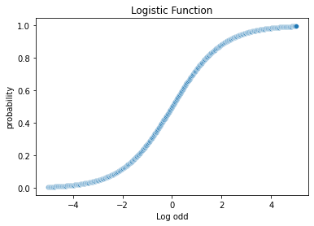

```python
# In programming, we can import numpy and seaborn
import numpy as np
import seaborn as sns

# First of all, we can use np.linspace to create an equally-spaced sequence from -5 to 5.
# I want the sequence to have small distance to each other so I set the number of elements to 500
x = np.linspace(-5,5,500)

# The scatterplot function in seaborn allow us to specify the points at x-axis and y-axis, and plot
# their relationship altogether
sns.scatterplot(x = x, y = 1/(1+np.exp(-x))).set(title = "Logistic Function", xlabel = "Log odd", ylabel = "probability")
```

### Question 2: What is log odd, odd and how to use log odd to define decision boundary for Logistic regression?

Before coding, we need to learn a terminology called **Log Odd**. We define the ratio of success over failure as **odd**. That is, we would divide the success probability over the failure probability (which is 1 - success probability) to get the odd. After that, we would take the log of the odd to get the log odd. Assume I can get up before 08:00 AM 60% of the time, then the success probability is 0.6.

```python
# and then the odd is 0.6 / ( 1 - 0.6)
odd = 0.6 / (1 - 0.6)
print("The odd of getting up before 8:00 AM:", odd)
# = 1.5, a value greater than 1.
```

```
The odd of getting up before 8:00 AM: 1.4999999999999998
```

```python
#  And if we take the log of it by using the np.log function,
import numpy as np
print("The log odd of getting up before 8:00 AM:", np.log(odd)) # Log odd
# We get log(1.5) = 0.405, which is a positive number. It is great to know that anytime when the probability
# of something happening is greater than 0.5, the log odd is a positive number, and this indicates the
# odd is in favor of what is going to happen. Otherwise if the log odd is a positive number, then we say the
# odd is against what is going to happen.

# To reiterate, Log odd = log(odd) = log(p / 1 - p), we need to keep in mind this quantity because it is
# exactly the value that the logistic regression would predict, for all regression coefficients and for all
# data put into the model.
```

```
The log odd of getting up before 8:00 AM: 0.4054651081081642
```

```python
# From log odd, therefore, we can convert it back to probability by the following computation.
# We exponentiate the log odd so we get an odd. And since odd = p / (1 - p), then
# odd * (1-p) = p, then odd = p * (1+odd), then the probability = odd / (1 + odd), or 1 / (1 + 1/odd) similar.

print("Probability of getting up before 8:00 AM:", np.exp(np.log(odd)) / (1 + np.exp(np.log(odd))))

# Cool! So we get back to the 0.6 probability. Now you may know how log odd and probability can convert
# to each other.
```

```
Probability of getting up before 8:00 AM: 0.5999999999999999
```

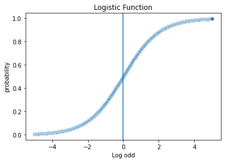

```python
# Bayesian logistic regression has proven capable of generating the predicting rules that will
# allow you to predict the winners of March Madness tournament based on a decision boundary.

decision_boundary = sns.scatterplot(x = x, y = 1/(1+np.exp(-x)))
decision_boundary.set(title = "Logistic Function", xlabel = "Log odd", ylabel = "probability")
decision_boundary.axvline(0)

# The decision boundary in Bayesian logistic regression is set to 0, because a 0 log odd corresponds with
# 0.5 in probability, which is when the success and failure probabilities are equal.
# Left decision boundary predicts losing the game, a failure.
# Right decision boundary predicts winning the game, a success.
```

Up till now we've looked at how the conversion of probability to odd and log odd looks like. Let's take a break here and continue the code journey in the next video!

# Video 2: Bayesian Logistic Regression - Modeling

In the last video we've discussed the concept of Bayesian Logistic Regression. This time we'll start right off for the dataset.

### Side Track: NCAA

The NCAA is a collegiate sport organization which hosts amazing sport events and competitions each year especially for college students. Some might not have heard of NCAA, so I picked two readings that are useful to get the background knowledge.

Read: https://www.ncaa.org/student-athletes/current

Read: https://en.wikipedia.org/wiki/NCAA_Division_I

Every March, the U.S. becomes captivated by the NCAA's Men's Basketball Tournament, also known as March Madness, in which 68 strong teams play single elimination tournament to fight for the nationship champion of NCAA Men's basketball. Except for the 4 matches to determine the 16th seeds, each of the 64 teams will be distributed to 4 regions. Each region has 16 teams seeded 1 to 16, depending on their AP rankings. To determine the match's result, we might want to take him to feature such as their AP ranking, the average point loss and gain throughout the season etc. In espn.com we might notice many cases when a lower seed as an underdog team won the game over a higher seed team in previous years. We want to predict the winners of games in these NCAA tournament games with the presence of these predictors, and find out what factors would affect how to fill out the Bracketology.

So our research lies primarily on predicting the winning probability and making decisions on who will win each of the tournament games based on seed, average point loss and average point gain. Because the result is binary, win or loss, nothing in between, so we can set up the Bayesian logistic regression model to measure such probability.

```python
# Now let's look at the data.
# The NCAA march madness data is collected from https://data.world/sports/ncaa-mens-march-madness/workspace/file?filename=NCAA+Mens+March+Madness+Historical+Results.csv
# where it records march madness matches since 1985. It's an interesting data about sport analytics
# that I found that at least three competing research groups have been trying to dig out the best techniques
# to predict outcomes based on several numerical features in the dataset.

# We can import the necessary package for data science works
import pymc3 as pm
import numpy as np
import theano.tensor as t
```

```python
# Now, let's import pandas for data manipulation and import a web dataset that stores NCAA Men's March
# Madness historical results since the 1980s.
import pandas as pd
march_madness = pd.read_csv('https://query.data.world/s/3cmo5s4axblcl2bh3sjtivo3xrhbox')
# and let's take a look about the complete data
march_madness
```

|  | Date | Round | Region | Winning Seed | Winner | Winning Score | Losing Seed | Loser | Losing Score | Overtime |
| --- | --- | --- | --- | --- | --- | --- | --- | --- | --- | --- |
| 0 | 3/14/85 | Round of 64 | East | 1 | Georgetown | 68 | 16 | Lehigh | 43 | NaN |
| 1 | 3/14/85 | Round of 64 | East | 4 | Loyola, Illinois | 59 | 13 | Iona | 58 | NaN |
| 2 | 3/14/85 | Round of 64 | East | 5 | Southern Methodist | 85 | 12 | Old Dominion | 68 | NaN |
| 3 | 3/14/85 | Round of 64 | East | 8 | Temple | 60 | 9 | Virginia Tech | 57 | NaN |
| 4 | 3/14/85 | Round of 64 | Midwest | 1 | Oklahoma | 96 | 16 | North Carolina A&T | 83 | NaN |
| ... | ... | ... | ... | ... | ... | ... | ... | ... | ... | ... |
| 2045 | 3/27/16 | Elite Eight | East | 1 | North Carolina | 88 | 6 | Notre Dame | 74 | NaN |
| 2046 | 3/27/16 | Elite Eight | Midwest | 10 | Syracuse | 68 | 1 | Virginia | 62 | NaN |
| 2047 | 4/2/16 | National Semifinals | NaN | 1 | North Carolina | 83 | 10 | Syracuse | 66 | NaN |
| 2048 | 4/2/16 | National Semifinals | NaN | 2 | Villanova | 95 | 2 | Oklahoma | 51 | NaN |
| 2049 | 4/4/16 | National Championship | NaN | 2 | Villanova | 77 | 1 | North Carolina | 74 | NaN |

2050 rows × 10 columns

```python
# Let's also look at its shape
march_madness.shape
```

```
(2050, 10)
```

We have a rich dataset that records a total of 1024 NCAA tournament plays in the first round of march madness that spans more than 20 years. Although the data is far from comprehensive, (it only contains the match outcomes, team seed, and scores), we can try the Bayesian logistic regression and take the outcome as the binary result and see how accurate the predictions we can get.

### Research Questions:

There may be various interesting questions to get an answer from our prior knowledge and from the data to gain insight about the NCAA tournament, and more specifically, many people may make better Bracketology predictions to clinch the leaderboard. Okay, I listed a few frequently asked questions.

- 1. What is the estimated decision boundary of predicting the winner team for each March Madness game?
- 1. What is the predicted probability of each team's winning probability in the first-round March Madness game based only on the team's seed?

```python
# We are going to encode the win and loss as categorical variables with the numbers 0 and 1.

round_of_64 = march_madness[march_madness['Round'] == 'Round of 64']

win = round_of_64[['Date', 'Round', 'Region', 'Winning Seed', 'Winning Score']]
win['Seed'] = win['Winning Seed']
win['Score'] = win['Winning Score']
lose = round_of_64[['Date', 'Round', 'Region', 'Losing Seed', 'Losing Score']]
lose['Seed'] = lose['Losing Seed']
lose['Score'] = lose['Losing Score']

win['Outcome'] = 1
lose['Outcome'] = 0
```

[output not shown]

```python
# We then concatenate the dataset
combined = pd.concat([win,lose])

# and save this pandas DataFrame to a csv file.
combined.to_csv('assets/march_madness.csv')
```

```python
# Now let's import the data that specifically shows the round of 64 for the years before.
round_of_64 = pd.read_csv('assets/march_madness.csv')
# and look at the first few rows.
round_of_64.head()
```

|  | Unnamed: 0 | Date | Round | Region | Winning Seed | Winning Score | Seed | Score | Outcome | Losing Seed | Losing Score |
| --- | --- | --- | --- | --- | --- | --- | --- | --- | --- | --- | --- |
| 0 | 0 | 3/14/85 | Round of 64 | East | 1.0 | 68.0 | 1 | 68 | 1 | NaN | NaN |
| 1 | 1 | 3/14/85 | Round of 64 | East | 4.0 | 59.0 | 4 | 59 | 1 | NaN | NaN |
| 2 | 2 | 3/14/85 | Round of 64 | East | 5.0 | 85.0 | 5 | 85 | 1 | NaN | NaN |
| 3 | 3 | 3/14/85 | Round of 64 | East | 8.0 | 60.0 | 8 | 60 | 1 | NaN | NaN |
| 4 | 4 | 3/14/85 | Round of 64 | Midwest | 1.0 | 96.0 | 1 | 96 | 1 | NaN | NaN |

### Question 3: What kind of feature engineering should we consider before modeling this NCAA data?

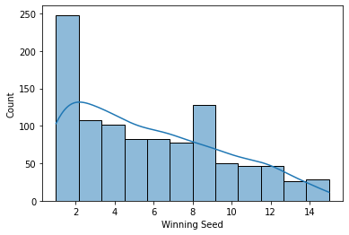

```python
# 1) Winning Seed at round of 64
# Seaborn is a very convenient visualization tool. Let's import seaborn.
import seaborn as sns
# Since we might know that all eligible teams for tournament are seeded 1 to 16, so we treat the team seed a
# categorical, or discrete variable. We can use histogram therefore to visualize the frequency distribution of
# winning given teams' seed.
sns.histplot(x = round_of_64['Winning Seed'], kde=True)

# Cool! Almost decreasing steadily from seed 1 to seed 16. Highest prob for first seed to get to the second round,
# and it features the least probability for 15 and 16th seed teams to advance to the second round.
```

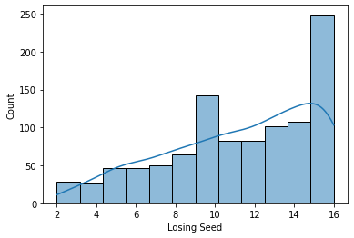

```python
# 2) Losing Seed round_of_64

# It's always nice to check different features and see other interesting patterns.
sns.histplot(x = round_of_64['Losing Seed'], kde = True)

# We can tell directly that it will show the lowest frequency for the first seed teams and the highest frequency for
# the lowest seed teams because the losing teams are the rival teams to the winning teams. Cool!
```

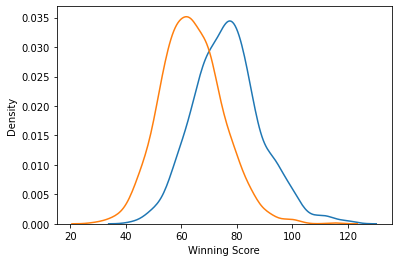

```python
# 3) Winning and Losing Score

# Let's now compare the winning and losing scores among 1000+ 64th round games.
# We can plot two kdeplots using the kdeplot function to compare the distribution of winning game scores
sns.kdeplot(x = round_of_64['Winning Score'])
# and the distribution of losing game scores.
sns.kdeplot(x = round_of_64['Losing Score'])

# By looking at the graph, we can see that both distributions look quite symmetric, with the highest density
# located at around 60 and 80, respectively. Could we just say that there are 20 points difference happening
# per game on average? If that's true, many people might be surprised!
```

```
11.0
```

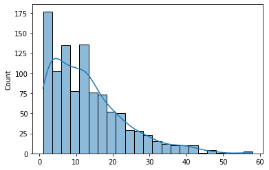

```python
# 4) Winning Margin Distribution = Winning Score - Losing Score

# But we can't directly draw the difference in winning and losing score. We need to first drop all non-applicable
# values called NAs and convert the pd.Series() into two separate np.arrays as multi-dimensional arrays, only then
# we are taking their differences. Let's see the plot.

# Because the winning margin should always be an integer, we could not draw a kdeplot here or otherwise will return
# error message
sns.histplot(x = np.array(round_of_64['Winning Score'].dropna()) - np.array(round_of_64['Losing Score'].dropna()), kde = True)

# Great! So by observation, I think the winning margin for an average game, depending on how to interpret, would
# better use its median value, instead of mean value, because there were certain 10s of extremely lopsided games
# raising the average winning margin up.

# The winning margin at the median should be around 10.
print(np.median(np.array(round_of_64['Winning Score'].dropna()) - np.array(round_of_64['Losing Score'].dropna())))
```

It's clear that we should predict the winning margin be approximately 10 points in an average game.

### Question 4: How could we create a Bayesian logistic regression model using PyMC3?

```python
# In a similar fashion, we start by defining a context manager and this time we call it NCAA_prediction_model.

with pm.Model() as NCAA_prediction_model:
    # To make a regression model, we treat everything as a random variable as ultimately we want to know
    # the posterior probability distribution of the parameters and in this case, the regression
    # coefficients.

    # Getting back to logistic regression, we need to specify a prior and likelihood in order to
    # draw samples from the posterior distribution.
    # Here we need to first understand what the initial effect means to us. An initial effect here is the log odds
    # of a certain team (with seed = 0 and score = 0) winning the first round NCAA tournament game. Although
    # it's impossible the score 0 in a game, and a team is seeded as 0, certain patterns could be inferred.

    # From the data visualizations, we are clear that the larger number of seeds indicates a lower chance of
    # winning, while scoring more points leads to higher probability of winning a game. Since seeding and
    # scoring points are conflicting, we can tell the system that we're highly unsure of the initial effect
    # by setting the mu parameter as 0, and sd to be like 3, which is a large value in terms of the change
    # of log odds.
    intercept = pm.Normal("intercept", mu=0, sd = 3)

    # Specify seed effect: Recall that the higher the team's seed, the higher the probability of the team
    # losing the game. Therefore, we can quantify the diminishing probability when the number of seeds
    # increases by setting a negative effect on log odds. I choose to initialize at -0.2 as I think the change
    # in log odds from the top seed to the 16th seed should change approximately from 90% to 10%. Here I
    # implied some mathematical calculations but just take it as a value that indicates decreasing probability
    # when team's seed increases.
    seed = pm.Normal("seed", mu=-0.2, sd = 3)

    # Specify score effect: Recall that the more points scored, the higher the probability of the team
    # winning the game. Therefore, we can quantity the increasing probability when team score rises by
    # setting a positive effect on log odds in the mu option. I choose to initialize at 0.03 because I think
    # the change in log odds per point could be small but not negligible. Since the effect of one point is
    # expected to have minor effect on the winning probability, I also set a smaller number in the sd option
    # where the standard deviation of the score effect, to 0.5. Cool!
    score = pm.Normal('score', mu= 0.03, sd = 0.5)

    # Likelihood: In likelihood of Logistic regression, we typically define the regression effect as log odds.
    # We denote z as the log odds of winning the 64th round game. The log odds is computed through the intercept,
    # adds the seed number times the seed effect, and adds the number of points scored times the scoring effect.
    z = intercept + seed * round_of_64['Seed'] + score * round_of_64['Score']

    # Finally, we convert the regression effect to probability, by taking a (sigmoid) transformation where we divide
    # 1 by 1 plus the exponentiated form of the log odd. This is actually the predictive probability of that
    # team winning the game. So this quantity represents the probability parameter of the pm.Bernoulli likelihood.
    # Subsequently, we should specify the observed data as the win or lose outcome column from the 64th round
    # competition data.
    yhat = pm.Bernoulli("yhat", 1 / (1 + t.exp(-z)), observed=round_of_64['Outcome'])
    # Now as we're modeling success and failure outcomes, a kind of binary data, we want to set a higher number
    # of posterior samples in order to ensure that we have a high chance to get reliable and unautocorrelated
    # posterior samples and make meaningful posterior diagnostics and interpretation. Again, we want to experiment
    # three groups of games and get a simulation from each chain, and each simulation has the first 2000 samples
    # discarded.
    trace = pm.sample(10000, chains = 3, tune = 2000)

    # Cool!
```

100.00% [36000/36000 01:00<00:00 Sampling 3 chains, 0 divergences]

```
Sampling 3 chains for 2_000 tune and 10_000 draw iterations (6_000 + 30_000 draws total) took 72 seconds.
```

```
array([[<AxesSubplot:title={'center':'intercept'}>,
        <AxesSubplot:title={'center':'intercept'}>],
       [<AxesSubplot:title={'center':'seed'}>,
        <AxesSubplot:title={'center':'seed'}>],
       [<AxesSubplot:title={'center':'score'}>,
        <AxesSubplot:title={'center':'score'}>]], dtype=object)
```

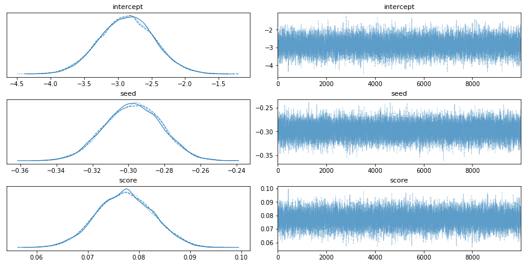

```python
# Traceplot
# We can import the arviz package for posterior diagnostics.
import arviz as az

# Let's make a trace plot to take a glimpse about the distribution and variability of posterior samples.
pm.traceplot(trace)

# Cool! We now see that the initial effect of a team winning a game is at around -3 in log odds based on the
# highest posterior density, which represents
# less than 0.5 probability so that the team tends to lose given if the team scored no point at all.
# That's so true right?!

# As you can see the seed row, we found that the lower seed rank for each will reduce the log odds of winning the
# game by around 0.3 unit based on the highest posterior density.

# Now you can see the score row, we found that the higher points scored in a game will boost the log odds of winning
# the game by around 0.08 per point increase, based on the highest posterior density.

# From the right panel, the simulated samples are mostly similar in fluctuation behaviours. We don't see any
# special patterns that indicate any chain is off from other chains.
```